# Introdução à Ciência de Dados

Mestrado em Administração  
Aula 11

Prof. Washington Santos da Silva

IFMG - Campus Formiga

21 de maio de 2026

## Nesta Aula

**Módulo: Fundamentos de Probabilidade e Simulação**

Esta é a quarta aula do módulo:

1. Fundamentos de probabilidade
2. Variáveis aleatórias e distribuições de probabilidade
3. Distribuições essenciais, simulação e ponte para inferência
4. **Noções de Simulação de Monte Carlo**

> “Essentially, all models are wrong, but some are useful.”

— George E. P. Box e Norman R. Draper, *Empirical Model-Building and Response Surfaces* (1987)

# Noções de Simulação de Monte Carlo

## Distribuição Uniforme Contínua

**O que é a Distribuição Uniforme Contínua?**

A **distribuição uniforme contínua no intervalo [0, 1]**, denotada $Y \sim U(0,1)$, descreve um fenômeno onde todos os valores do intervalo são **igualmente prováveis**.

**Propriedades Fundamentais**

- O suporte é o intervalo unitário:

$$Y \in [0, 1]$$

- A fdp é constante:

$$f(y) =
\begin{cases}
1, & \text{se } 0 \leq y \leq 1 \\
0, & \text{caso contrário}
\end{cases}$$

- A área sob a curva é 1 (como toda função densidade de probabilidade):

  $$\int_0^1 f(y) \, dy = 1$$
- Probabilidades são proporcionais ao comprimento do intervalo:

  $$P(Y \in [a, b]) = b - a, \quad \text{para } 0 \leq a < b \leq 1$$

## Distribuição Uniforme Contínua

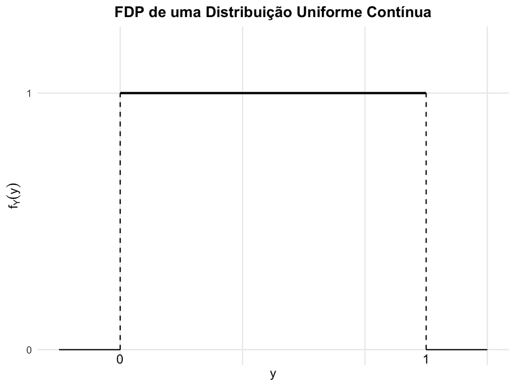

## Distribuição $U(0,1)$ — por que é importante?

**Papel fundamental em simulação**

A distribuição $U(0,1)$ é a **matéria-prima** dos algoritmos de geração de números pseudoaleatórios. Geradores como `runif()` em R produzem amostras de $U(0,1)$, e a partir delas obtemos amostras de **qualquer outra distribuição** por meio de transformações adequadas.

Por isso, a $U(0,1)$:

- é a **base das simulações de Monte Carlo**;
- viabiliza a **simulação de variáveis aleatórias** de distribuições como normal, exponencial, binomial, entre outras.

## Transformações da Uniforme

**De $U(0,1)$ para qualquer distribuição**

Se $U \sim U(0,1)$, podemos gerar uma variável aleatória $X$ com distribuição desejada $F_X$ (função de distribuição acumulada) usando:

$$X = F_X^{-1}(U)$$

Esse método é chamado de **Transformação Inversa da Função de Distribuição Acumulada**.

Ou seja, a FDA mapeia $X \to [0,1]$ uniformemente; portanto sua inversa permite reconstruir $X$ a partir de sorteios uniformes.

## Exemplo 1

**Objetivo: simular $X \sim \text{Exponencial}(\lambda)$**

Gerar $X \sim \text{Exponencial}(\lambda)$ a partir de $U \sim U(0,1)$.

#### Função de distribuição acumulada

$$F_X(x) = 1 - e^{-\lambda x}, \qquad x \geq 0$$

#### Estratégia

Pelo método da inversa da CDF:

$$X = F_X^{-1}(U), \qquad U \sim \text{Uniforme}(0,1)$$

Partindo de:

$$\begin{aligned}
F_X(x) &= 1 - e^{-\lambda x} \\
u &= 1 - e^{-\lambda x}
\end{aligned}$$

Isolando $x$:

$$e^{-\lambda x} = 1 - u$$

$$-\lambda x = \ln(1 - u)$$

$$\boxed{\; x = -\frac{1}{\lambda}\,\ln(1 - u) \;}$$

## Exemplo 1

**Por que usar $\ln(U)$ em vez de $\ln(1-U)$?**

Como $U \sim U(0,1)$, também $1 - U \sim U(0,1)$. A distribuição uniforme é **simétrica** em torno de $0{,}5$, portanto qualquer transformação aplicada a $U$ ou a $1-U$ resulta na **mesma distribuição**.

Por **conveniência computacional**, utilizamos:

$$X = -\frac{1}{\lambda}\,\ln(U)$$

O valor resultante segue exatamente a mesma distribuição $\text{Exponencial}(\lambda)$.

## Exemplo 1 — Implementação em R

```r
# fixa a semente
set.seed(42)

# simula U ~ Uniforme(0,1)
u  <- runif(10000)

# define o parâmetro da Exponencial
lambda <- 2

# gera X ~ Exponencial(lambda)
x <- -log(u) / lambda
```

**Transformada Inversa da FDA**

Geramos 10.000 valores de $\text{Exponencial}(\lambda=2)$ aplicando $X = -\ln(U)/\lambda$ a uma amostra uniforme.

## Histograma com densidade sobreposta

```r
# --- 3. Histograma da amostra simulada ------------------------------------
hist(x,
     breaks      = 30,           # número de classes do histograma
     col         = "orange",     # cor das barras
     probability = TRUE,         # escala em densidade (área total = 1)
     main = expression("Exponencial(" * lambda == 2 * ") via U(0,1)"),
     xlab = "x",
     ylab = "densidade")


# --- 4. Densidade teórica sobreposta --------------------------------------
curve(dexp(x, rate = lambda),    # f(x) = lambda * exp(-lambda * x)
      add = TRUE,                # adiciona ao gráfico existente
      col = "blue", lwd = 2)

# --- 5. Legenda -----------------------------------------------------------
legend("topright",
       legend = c("Histograma simulado", "Densidade teórica"),
       col    = c("orange", "blue"),
       lwd    = c(8, 2),
       lty    = 1,
       bty    = "n")
```

## Exemplo 1

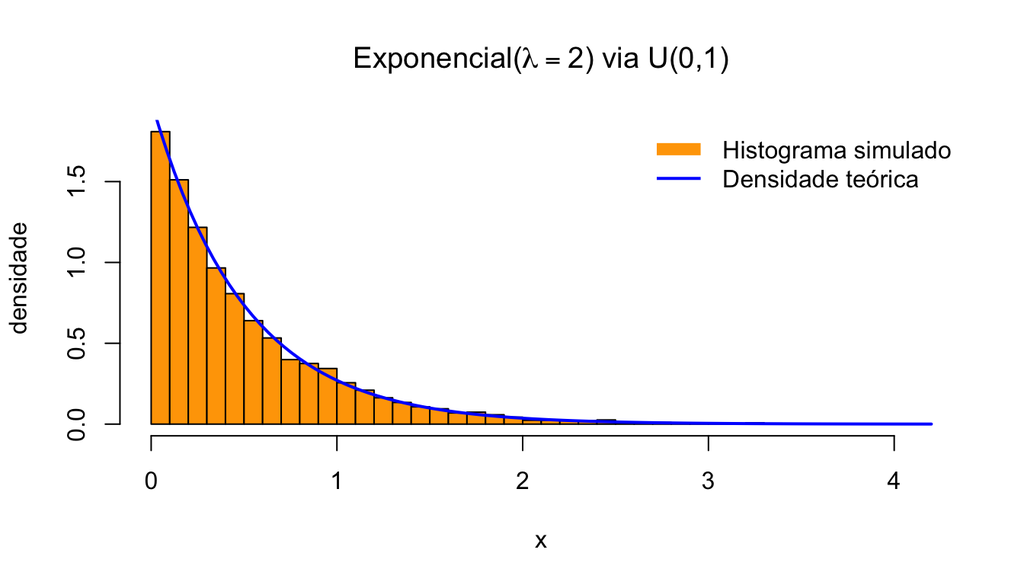

Histograma da amostra simulada da Exponencial(2)

## Síntese

**Importância da distribuição $U(0,1)$**

A distribuição uniforme $U(0,1)$ é a **matéria-prima universal** para gerar variáveis aleatórias de qualquer outra distribuição. Os principais métodos são:

1. **Transformação inversa da CDF** — analítica quando $F_X^{-1}$ tem forma fechada (Exponencial, Weibull); numérica caso contrário (`qnorm()` para a Normal).
2. **Transformações específicas** — Box–Muller para a Normal; razão de uniformes para outras distribuições.
3. **Aceitação–rejeição** — quando a inversa não é viável, amostra-se de uma proposta e aceita-se com probabilidade calibrada.
4. **MCMC** — Metropolis–Hastings, Gibbs — quando a densidade-alvo só é conhecida a menos de constante normalizadora.

Assim, a $U(0,1)$ é a **pedra fundamental** dos métodos de Simulação de Monte Carlo.

## O problema da incerteza em decisões financeiras

**Cenário típico: avaliação de projeto**

Em uma análise determinística, cada parâmetro é tratado como um valor fixo. Considere o seguinte projeto:

[output not shown]

## O problema da incerteza em decisões financeiras

**Limitações da análise determinística**

A abordagem determinística:

- não descreve a **distribuição** dos resultados possíveis;
- não quantifica diretamente o **risco de insucesso** do projeto;
- não responde à pergunta central: *qual é a probabilidade estimada de o VPL ser positivo, dadas as incertezas assumidas?*

A **Simulação de Monte Carlo** ajuda a enfrentar essas limitações ao propagar a incerteza de cada parâmetro até a distribuição do VPL.

## Análise de viabilidade econômica sob incerteza

**Distribuição triangular**

A distribuição triangular é útil quando há pouca informação histórica, mas é possível definir três valores para uma variável incerta:

| Parâmetro | Interpretação |
| --- | --- |
| $a$ | valor mínimo possível |
| $b$ | valor máximo possível |
| $c$ | valor mais provável |

Essa distribuição é frequentemente usada em simulações de viabilidade econômica porque combina simplicidade com interpretação intuitiva.

Ela é especialmente adequada quando as estimativas são baseadas em experiência, julgamento técnico ou opinião de especialistas.

## Distribuição triangular

**Densidade, média e variância**

A função densidade de probabilidade da distribuição triangular é dada por:

$$f(x) =
\begin{cases}
\dfrac{2(x-a)}{(b-a)(c-a)}, & a \leq x < c, \\[6pt]
\dfrac{2(b-x)}{(b-a)(b-c)}, & c \leq x \leq b, \\[6pt]
0, & \text{caso contrário}.
\end{cases}$$

O valor esperado é:

$$E(X) = \frac{a + b + c}{3}$$

A variância é:

$$V(X) =
\frac{a^2 + b^2 + c^2 - ab - ac - bc}{18}$$

## Distribuição triangular

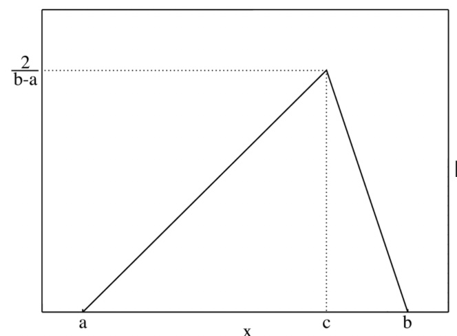

Função densidade de probabilidade da distribuição triangular

## Por que usar a distribuição triangular?

**Situações em que a distribuição triangular é adequada**

A distribuição triangular é uma escolha prática quando os dados são limitados, mas há conhecimento suficiente para definir valores mínimo, máximo e mais provável.

Ela é especialmente útil em três situações:

1. **Dados históricos escassos**

   Quando não há observações suficientes para ajustar uma distribuição mais complexa, mas especialistas conseguem indicar limites plausíveis.
2. **Parâmetros incertos em projetos bem definidos**

   Em projetos de investimento, construção, expansão ou lançamento de produtos, o escopo pode ser conhecido, embora custos, receitas e prazos ainda sejam incertos.
3. **Análises preliminares de viabilidade**

   Em fases iniciais, a distribuição triangular permite incorporar incerteza sem exigir grande volume de dados ou modelagem excessivamente complexa.

## Distribuição triangular em R

**Simulação de valores aleatórios**

Para simular valores de uma distribuição triangular em R, é necessário definir:

| Símbolo | Descrição |
| --- | --- |
| `a` | limite mínimo |
| `b` | limite máximo |
| `c` | valor mais provável |
| `n` | número de simulações |

Sintaxe:

```r
# carrega o pacote
library(triangulr)

# sintaxe da função
rtri(n, a, b, c)
```

No contexto de análise de projetos, essa função pode ser usada para simular custos, receitas, prazos ou taxas de desconto.

## Escolha de distribuições em simulações financeiras

**Critérios práticos de escolha**

A escolha da distribuição deve refletir o tipo de informação disponível sobre cada variável incerta.

| Distribuição | Quando usar | Parâmetros principais | Exemplo |
| --- | --- | --- | --- |
| Uniforme | Todos os valores no intervalo são tratados como igualmente prováveis | mínimo, máximo | receita anual entre R$ 12 mil e R$ 16 mil |
| Triangular | Há estimativas para mínimo, máximo e valor mais provável | mínimo, máximo, moda | duração do projeto entre 7 e 10 anos, com valor mais provável de 8 anos |
| Normal | Há dados históricos ou justificativa para variações aproximadamente simétricas | média, desvio-padrão | retornos de uma carteira diversificada |

A distribuição não deve ser escolhida apenas por conveniência computacional. Ela deve representar, de forma coerente, o conhecimento disponível sobre a variável analisada.

## Exemplos em R

**Simulação de variáveis incertas**

Distribuição uniforme:

```r
receita <- runif(n, min = 12000, max = 16000)
```

Distribuição triangular:

```r
duracao <- rtri(n, a = 7, b = 10, c = 8)
```

Distribuição normal:

```r
retorno <- rnorm(n, mean = 0.08, sd = 0.12)
```

A distribuição normal deve ser usada com cautela para variáveis que não podem assumir valores negativos, como preços, quantidades, receitas e custos.

## Análise de viabilidade sob incerteza

**Simulação do VPL**

Vamos simular o VPL de um projeto de investimento usando:

$$\text{VPL} =
\sum_{t=1}^{\text{duração}}
\frac{\text{receita}_t}{(1 + \text{taxa})^t}
+
\frac{\text{valor residual}}{(1 + \text{taxa})^{\text{duração}}}
-
\text{investimento inicial}$$

Cada simulação representa um cenário possível para o projeto.

Nos próximos slides, usaremos funções do **tidyverse**, especialmente do pacote `purrr`, para simular cenários e calcular a distribuição do VPL.

## VPL determinístico vs. simulação

**Cálculo determinístico com parâmetros modais**

No cálculo determinístico, usamos apenas um valor para cada parâmetro do projeto.

**Parâmetros do cenário base:**

- investimento inicial: R$ 75.000;
- receita anual: R$ 14.000;
- duração: 10 anos;
- taxa de desconto: 13% ao ano;
- valor residual: R$ 5.000.

Se o VPL determinístico for positivo, o projeto é classificado como viável nesse cenário único.

## Cálculo determinístico com parâmetros modais

```r
# Define os parâmetros determinísticos do projeto
investimento_det <- 75000
receita_anual_det <- 14000
duracao_det <- 10
taxa_desconto_det <- 0.13
valor_residual_det <- 5000

# Cria a sequência de anos do projeto
anos_det <- seq_len(duracao_det)

# Calcula o valor presente das receitas anuais
vpl_receitas_det <- sum(
  receita_anual_det / (1 + taxa_desconto_det)^anos_det
)

# Calcula o valor presente do valor residual
vpl_residual_det <- valor_residual_det /
  (1 + taxa_desconto_det)^duracao_det

# Calcula o VPL determinístico
vpl_deterministico <- vpl_receitas_det +
  vpl_residual_det -
  investimento_det

# Exibe o VPL determinístico
vpl_deterministico
```

```
[1] 2440.4
```

## VPL determinístico vs. simulação

**Limitações da análise determinística**

A análise determinística é simples e útil como ponto de partida.

No entanto, ela apresenta limitações importantes:

- usa apenas valores pontuais;
- gera um único resultado para o VPL;
- não mostra a amplitude dos resultados possíveis;
- não quantifica a probabilidade de o projeto gerar VPL negativo.

A Simulação de Monte Carlo amplia a análise ao considerar várias combinações possíveis para os parâmetros incertos do projeto.

Com isso, a decisão deixa de depender apenas de um único VPL e passa a considerar a distribuição dos resultados simulados.

## Simulação de Monte Carlo com `purrr`

**Ideia central**

Em uma Simulação de Monte Carlo, repetimos o mesmo cálculo muitas vezes.

Neste exemplo, cada cenário simulado pode ter:

- investimento inicial diferente;
- receitas anuais diferentes;
- valor residual diferente;
- duração diferente;
- taxa de desconto diferente.

## Simulação de Monte Carlo com `purrr`

**Ideia central**

A estratégia será dividida em três etapas:

1. simular os cenários possíveis para o projeto;
2. criar uma função para calcular o VPL de um cenário;
3. aplicar essa função a todos os cenários simulados.

Essa organização separa a **simulação dos dados** do **cálculo do VPL**.

## Análise de viabilidade sob incerteza

**Simulação dos cenários**

```r
# Carrega os pacotes necessários
library(tidyverse)
library(triangulr)

# Define a semente para tornar os resultados reprodutíveis
set.seed(567)

# Define o número de cenários simulados
n_sim <- 100000

# Simula os parâmetros incertos de cada cenário
cenarios <- tibble(
  cenario = seq_len(n_sim),
  investimento = runif(n_sim, min = 65000, max = 85000),
  valor_residual = rtri(n_sim, 4000, 6000, 5000),
  duracao = round(rtri(n_sim, 9, 11, 10)),
  taxa_desconto = rtri(n_sim, 0.10, 0.15, 0.13)
)

# Simula as receitas anuais de cada cenário
# Como cada cenário pode ter duração diferente,
# o resultado precisa ser uma lista de vetores
cenarios <- cenarios |>
  mutate(
    receitas = map(
      duracao,
      \(n) runif(n, min = 12000, max = 16000)
    )
  )

# Visualiza os primeiros cenários simulados
cenarios |>
  slice_head(n = 5)
```

```
# A tibble: 5 × 6
  cenario investimento valor_residual duracao taxa_desconto receitas
    <int>        <dbl>          <dbl>   <dbl>         <dbl> <list>
1       1       79887.          5180.      11         0.120 <dbl [11]>
2       2       82509.          4910.      10         0.130 <dbl [10]>
3       3       77655.          4541.      10         0.132 <dbl [10]>
4       4       74787.          4498.      10         0.128 <dbl [10]>
5       5       70217.          4628.      10         0.116 <dbl [10]>
```

A função `map()` pertence à mesma família de funções de `map_dbl()`.

A diferença é que `map_dbl()` devolve um vetor numérico, enquanto `map()` devolve uma lista.

Neste slide, usamos `map()` porque cada cenário pode gerar um vetor de receitas com tamanho diferente.

## Análise de viabilidade sob incerteza

**Por que usar `map()` e uma coluna-lista?**

A função `map_dbl()` é adequada quando cada aplicação da função devolve um único número.

Neste caso, porém, cada cenário precisa guardar um vetor de receitas anuais:

- se a duração for de 9 anos, o vetor terá 9 receitas;
- se a duração for de 10 anos, o vetor terá 10 receitas;
- se a duração for de 11 anos, o vetor terá 11 receitas.

Como os resultados têm tamanhos diferentes, não podemos armazená-los em uma coluna numérica comum.

Por isso, usamos `map()` para criar uma **coluna-lista**, em que cada linha contém um vetor de receitas anuais.

## Análise de viabilidade sob incerteza

**Função para calcular o VPL**

Depois de simular os cenários, criamos uma função para calcular o VPL de um único cenário.

```r
# Define uma função para calcular o VPL de um cenário
calcular_vpl <- function(investimento,
                         receitas,
                         valor_residual,
                         taxa_desconto) {

  # Cria a sequência de anos do projeto
  anos <- seq_along(receitas)

  # Calcula o valor presente das receitas
  vpl_receitas <- sum(
    receitas / (1 + taxa_desconto)^anos
  )

  # Calcula o valor presente do valor residual
  vpl_residual <- valor_residual /
    (1 + taxa_desconto)^length(receitas)

  # Retorna o VPL total do cenário
  vpl_receitas + vpl_residual - investimento
}
```

A função não simula novos valores.

Ela recebe os valores já simulados de um cenário e devolve o VPL correspondente.

## Análise de viabilidade sob incerteza

**Calculando o VPL dos cenários simulados**

Depois de definir a função `calcular_vpl()`, podemos aplicá-la aos cenários simulados usando `pmap_dbl()`.

```r
# Calcula o VPL de cada cenário simulado
simulacoes <- cenarios |>
  mutate(
    vpl = pmap_dbl(
      .l = list(
        investimento = investimento,
        receitas = receitas,
        valor_residual = valor_residual,
        taxa_desconto = taxa_desconto
      ),
      .f = calcular_vpl
    )
  )

# Visualiza os primeiros resultados da simulação
simulacoes |>
  select(
    cenario,
    investimento,
    valor_residual,
    duracao,
    taxa_desconto,
    vpl
  ) |>
  slice_head(n = 5)
```

```
# A tibble: 5 × 6
  cenario investimento valor_residual duracao taxa_desconto    vpl
    <int>        <dbl>          <dbl>   <dbl>         <dbl>  <dbl>
1       1       79887.          5180.      11         0.120  2762.
2       2       82509.          4910.      10         0.130 -7445.
3       3       77655.          4541.      10         0.132 -1509.
4       4       74787.          4498.      10         0.128  5641.
5       5       70217.          4628.      10         0.116  9976.
```

Em `pmap_dbl()`:

- `.l` indica a lista de entradas usadas no cálculo;
- `.f` indica a função aplicada a essas entradas;
- `_dbl` indica que o resultado será um vetor numérico.

No argumento `.l`, cada item segue a estrutura:

```r
argumento_da_funcao = coluna_da_tabela
```

Neste exemplo, os nomes à esquerda correspondem aos argumentos de `calcular_vpl()`, e os nomes à direita correspondem às colunas da tabela `cenarios`.

A função `pmap_dbl()` combina esses vetores linha a linha e aplica `calcular_vpl()` a cada cenário simulado.

## Análise de viabilidade sob incerteza

**Interpretação econômica da simulação**

Cada linha da tabela `simulacoes` representa um cenário possível para o projeto.

Em cada cenário:

- o investimento inicial é sorteado dentro do intervalo assumido;
- a duração do projeto pode variar;
- a taxa de desconto pode assumir diferentes valores;
- as receitas anuais são simuladas de acordo com a duração do projeto;
- o VPL é calculado com base nesses valores.

Assim, a coluna `vpl` contém uma distribuição simulada de resultados econômicos possíveis para o projeto.

Essa distribuição será usada para avaliar não apenas se o VPL típico é positivo, mas também o risco de o projeto gerar VPL negativo.

## Análise de viabilidade sob incerteza

**Estatísticas da simulação**

```r
# Calcula estatísticas resumidas dos VPLs simulados
resumo_vpl <- simulacoes |>
  summarise(
    vpl_mediana = median(vpl),
    vpl_p5 = quantile(vpl, 0.05),
    vpl_p95 = quantile(vpl, 0.95),
    prob_viavel = mean(vpl > 0) * 100,
    prob_inviavel = mean(vpl <= 0) * 100
  )

# Exibe o resumo da simulação
resumo_vpl
```

```
# A tibble: 1 × 5
  vpl_mediana vpl_p5 vpl_p95 prob_viavel prob_inviavel
        <dbl>  <dbl>   <dbl>       <dbl>         <dbl>
1       3524. -8226.  15401.        67.0          33.0
```

A simulação permite estimar não apenas um VPL típico, mas também a dispersão dos resultados e a probabilidade de inviabilidade econômica.

## Distribuição do VPL simulado

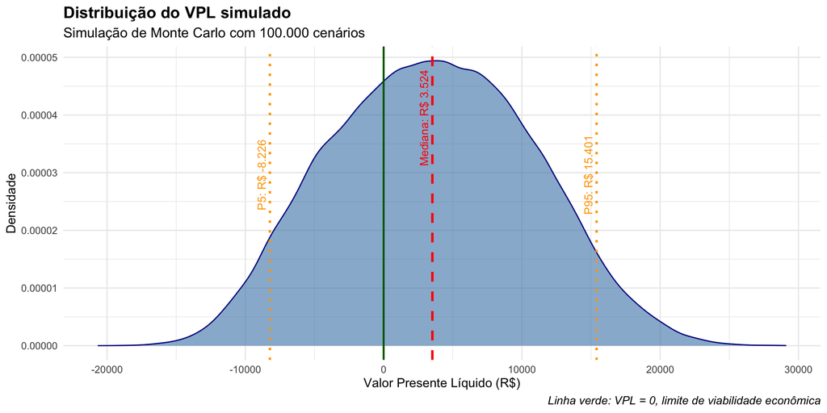

## Resultados

**Análise determinística vs. Simulação de Monte Carlo**

```r
# Calcula estatísticas resumidas da simulação
resumo_vpl <- simulacoes |>
  summarise(
    prob_viavel = mean(vpl > 0) * 100,
    prob_inviavel = mean(vpl <= 0) * 100,
    vpl_mediana = median(vpl),
    vpl_p5 = quantile(vpl, 0.05),
    vpl_p95 = quantile(vpl, 0.95)
  )

# Extrai os resultados para uso no texto do slide
prob_viavel <- resumo_vpl$prob_viavel
prob_inviavel <- resumo_vpl$prob_inviavel
vpl_mediana <- resumo_vpl$vpl_mediana
vpl_p5 <- resumo_vpl$vpl_p5
vpl_p95 <- resumo_vpl$vpl_p95
```

| Métrica | Análise determinística | Simulação de Monte Carlo |
| --- | --- | --- |
| VPL | R$ 2.440 | Mediana: R$ 3.524 |
| Incerteza | Valor único | P5: R$ -8.226; P95: R$ 15.401 |
| Decisão | Viável | Avaliação probabilística |

A simulação permite estimar:

- 67% de probabilidade de VPL positivo;
- 33% de probabilidade de VPL negativo ou nulo.

Os percentis P5 e P95 delimitam um intervalo que contém aproximadamente 90% dos VPLs simulados.

## Resultados

**O que a simulação acrescenta?**

A Simulação de Monte Carlo transforma uma análise baseada em um único cenário em uma avaliação probabilística.

Ela permite:

- estimar a probabilidade de viabilidade econômica;
- quantificar o risco de VPL negativo;
- visualizar a dispersão dos resultados possíveis;
- comparar cenários com diferentes graus de risco.

Em aplicações mais complexas, a simulação também pode incorporar:

- correlações entre variáveis;
- cenários macroeconômicos;
- restrições orçamentárias;
- portfólios de projetos.

Assim, a decisão deixa de ser apenas “viável” ou “inviável” e passa a considerar o risco associado ao projeto.

# Exercícios

## Exercício 1

**Enunciado**

A distribuição Logística possui função de distribuição acumulada dada por:

$$F(x) = \frac{1}{1 + e^{-(x - \mu)/\beta}}$$

Gere 10.000 variáveis aleatórias que seguem esta distribuição usando a transformação inversa.

## Exercício 2

**Simulação do Índice de Liquidez Rápida**

O **Índice de Liquidez Rápida (ILR)** mede a capacidade de uma empresa pagar suas obrigações de curto prazo sem depender da venda de estoques:

$$\text{ILR} = \frac{\text{Ativo Circulante} - \text{Estoques}}{\text{Passivo Circulante}}$$

**Cenário**: Você é analista financeiro de uma empresa do setor de varejo e precisa avaliar o risco de liquidez sob incerteza.

**Informações dos especialistas** (baseadas em dados setoriais):

- **Ativo Circulante**: entre R$ 800 mil e R$ 1.200 mil (mais provável: R$ 950 mil)
- **Estoques**: entre R$ 200 mil e R$ 400 mil (mais provável: R$ 280 mil)
- **Passivo Circulante**: entre R$ 600 mil e R$ 900 mil (mais provável: R$ 720 mil)

**Questões**:

Use `set.seed(2024)` e

1. **Simule 20.000 cenários** do ILR usando distribuições triangulares
2. **Calcule $P(\text{ILR} < 1)$** e interprete o resultado
3. **Compare** o ILR médio simulado com o modelo determinístico (valores mais prováveis)
4. **Recomende ações** se a probabilidade de ILR < 1 for maior que 40%